# Interpretability

Àlex Martorell, Enric Reverter, Pim Schoolkate

24/12/2022

```r
library(randomForest)
library(ranger)
library(vip)
library(fastshap)
library(DALEX)
library(mgcv)
library(DALEXtra)
library(lime)
library(iml)
library(localModel)
library(ggplot2)
```

```r
library(readxl)
concrete <- as.data.frame(read_excel("Concrete_Data.xls"))
DescVars <- names(concrete)
names(concrete) <- c("Cement","Slag","FlyAsh","Water","Superplast",
"CoarseAggr","FineAggr","Age","Strength")
```

```r
df<-concrete
```

```r
set.seed(42)
s <- (sample(1:nrow(df), size = 700))
train <- df[s, ]
test <- df[-s, ]
```

# 1. Fit a Random Forest

Split criteria is measured as the sum of the variance of the response variable for each node in the tree for a regression problem as such. Thus splitting criteria is:

$$C(T) - C(T') = N_rQ_r - (N_{r'}Q_{r'} + N_{r''}Q_{r''})$$
Where $Q_r$ is a measure of the impurity (in this case variance of response variable) at node $r$. Meaning that if $C(T) - C(T')$ is larger than zero, a split is justified.

Importance is measured as the impurity of each node which is defined as the variance of the response variable as well.

```r
model_rf_imp <- ranger(
  Strength ~ .,
  data = train,
  importance='impurity'
)
print(model_rf_imp)
```

```
## Ranger result
##
## Call:
##  ranger(Strength ~ ., data = train, importance = "impurity")
##
## Type:                             Regression
## Number of trees:                  500
## Sample size:                      700
## Number of independent variables:  8
## Mtry:                             2
## Target node size:                 5
## Variable importance mode:         impurity
## Splitrule:                        variance
## OOB prediction error (MSE):       34.53954
## R squared (OOB):                  0.877664
```

Out of bag permutations measures the influence of the variable on the Sample squared error. Thus the importance should be seen as the sum of the differences of the sample squared error of the out of bag samples with the sample squared error of the out of bag samples for which the variable as been permuted.

```r
model_rf_perm <- ranger(
  Strength ~ .,
  data = train,
  importance='permutation'
)
print(model_rf_perm)
```

```
## Ranger result
##
## Call:
##  ranger(Strength ~ ., data = train, importance = "permutation")
##
## Type:                             Regression
## Number of trees:                  500
## Sample size:                      700
## Number of independent variables:  8
## Mtry:                             2
## Target node size:                 5
## Variable importance mode:         permutation
## Splitrule:                        variance
## OOB prediction error (MSE):       35.68536
## R squared (OOB):                  0.8736056
```

As can be seen, both measures find almost identical results, with the exception of the slag and FineAggr, where slag is more important in the eyes of the out of bag permutations and FineAggr is more important when using impurity at splits.

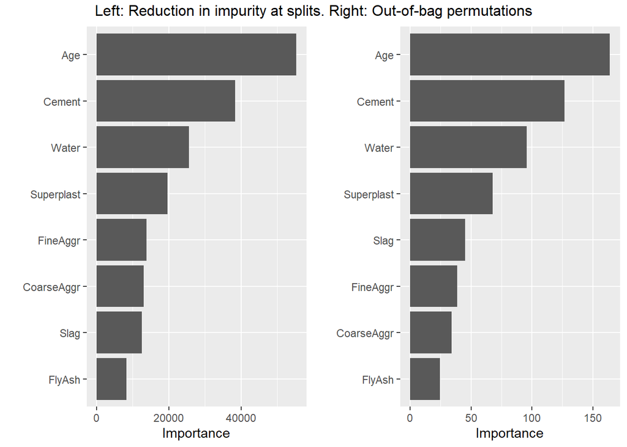

```r
rf_imp_vip <- vip(model_rf_imp, num_features = 8)
rf_perm_vip <- vip(model_rf_perm, num_features = 8)
grid.arrange(rf_imp_vip, rf_perm_vip, ncol=2, top="Left: Reduction in impurity at splits. Right: Out-of-bag permutations")
```

Shapley values confirm the importance findings of both the impurity and out-of-bag permutation measures.

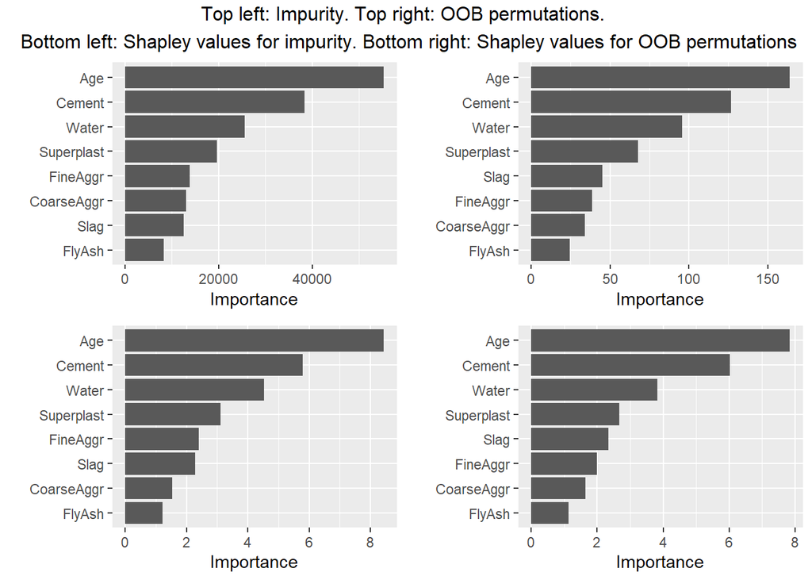

```r
rf_imp_vip <- vip(model_rf_imp, num_features = 8)
rf_perm_vip <- vip(model_rf_perm, num_features = 8)
rf_shapley_imp <- vip(model_rf_imp, method="shap",
                    pred_wrapper=yhat, num_features = 8,
                  newdata=test[,-9])
rf_shapley_perm <- vip(model_rf_perm, method="shap",
                    pred_wrapper=yhat, num_features = 8,
                  newdata=test[,-9])
grid.arrange(rf_imp_vip, rf_perm_vip, rf_shapley_imp, rf_shapley_perm,
             ncol=2, nrow=2,
             top="Top left: Impurity. Top right: OOB permutations. \n Bottom left: Shapley values for impurity. Bottom right: Shapley values for OOB permutations"
            )
```

# 2 Fit a linear model and a gam model.

```r
lm_concrete <- lm(Strength ~ ., data = train)
(summ_lm_concrete <- summary(lm_concrete))
```

```
##
## Call:
## lm(formula = Strength ~ ., data = train)
##
## Residuals:
##     Min      1Q  Median      3Q     Max
## -29.003  -6.253   0.355   6.380  34.288
##
## Coefficients:
##               Estimate Std. Error t value Pr(>|t|)
## (Intercept) -37.444031  32.441685  -1.154  0.24882
## Cement        0.122253   0.010483  11.661  < 2e-16 ***
## Slag          0.111016   0.012583   8.823  < 2e-16 ***
## FlyAsh        0.094141   0.015581   6.042 2.49e-09 ***
## Water        -0.130398   0.048175  -2.707  0.00696 **
## Superplast    0.324301   0.110096   2.946  0.00333 **
## CoarseAggr    0.023198   0.011473   2.022  0.04356 *
## FineAggr      0.025225   0.013078   1.929  0.05418 .
## Age           0.113435   0.006538  17.349  < 2e-16 ***
## ---
## Signif. codes:  0 '***' 0.001 '**' 0.01 '*' 0.05 '.' 0.1 ' ' 1
##
## Residual standard error: 10.27 on 691 degrees of freedom
## Multiple R-squared:  0.6308, Adjusted R-squared:  0.6265
## F-statistic: 147.6 on 8 and 691 DF,  p-value: < 2.2e-16
```

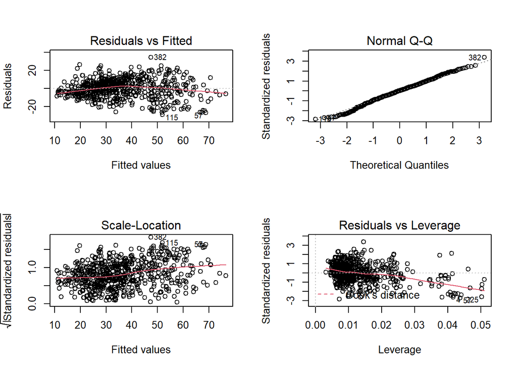

```r
par(mfrow=c(2,2))
plot(lm_concrete)
```

It is observed that all variables have a non-linear effect over the response variable, because edf > 1. This is also observed when plotting the GAM.

```r
gam_concrete <- gam(Strength ~ s(Age) + s(Cement) + s(Slag) + s(FlyAsh) + s(Superplast) + s(CoarseAggr) + s(FineAggr) + s(Water),
                 data = train)
(summ_gam_concrete <- summary(gam_concrete))
```

```
##
## Family: gaussian
## Link function: identity
##
## Formula:
## Strength ~ s(Age) + s(Cement) + s(Slag) + s(FlyAsh) + s(Superplast) +
##     s(CoarseAggr) + s(FineAggr) + s(Water)
##
## Parametric coefficients:
##             Estimate Std. Error t value Pr(>|t|)
## (Intercept)  36.0285     0.2035     177   <2e-16 ***
## ---
## Signif. codes:  0 '***' 0.001 '**' 0.01 '*' 0.05 '.' 0.1 ' ' 1
##
## Approximate significance of smooth terms:
##                 edf Ref.df       F p-value
## s(Age)        8.266  8.725 237.356 < 2e-16 ***
## s(Cement)     7.798  8.615  28.737 < 2e-16 ***
## s(Slag)       8.240  8.810  14.212 < 2e-16 ***
## s(FlyAsh)     8.085  8.732   5.080 2.6e-06 ***
## s(Superplast) 8.126  8.782   7.862 < 2e-16 ***
## s(CoarseAggr) 7.187  8.175   1.737  0.0789 .
## s(FineAggr)   8.556  8.932  11.849 < 2e-16 ***
## s(Water)      8.506  8.916  18.461 < 2e-16 ***
## ---
## Signif. codes:  0 '***' 0.001 '**' 0.01 '*' 0.05 '.' 0.1 ' ' 1
##
## R-sq.(adj) =  0.897   Deviance explained = 90.7%
## GCV = 32.004  Scale est. = 28.998    n = 700
```

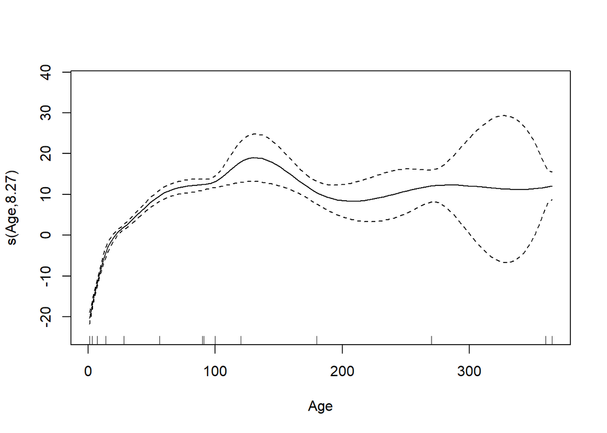

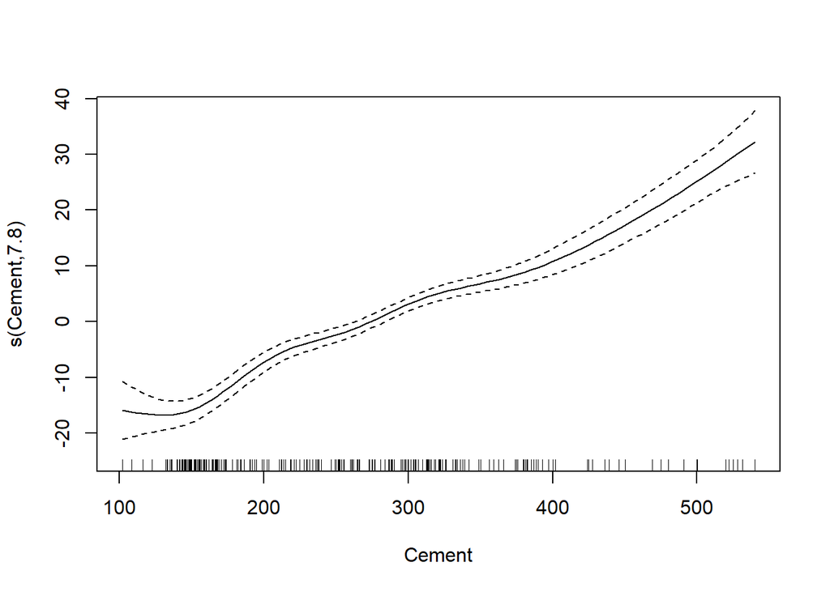

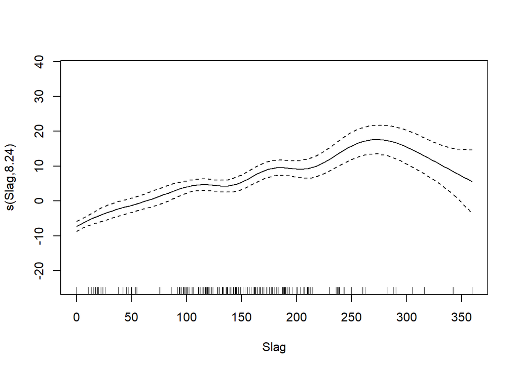

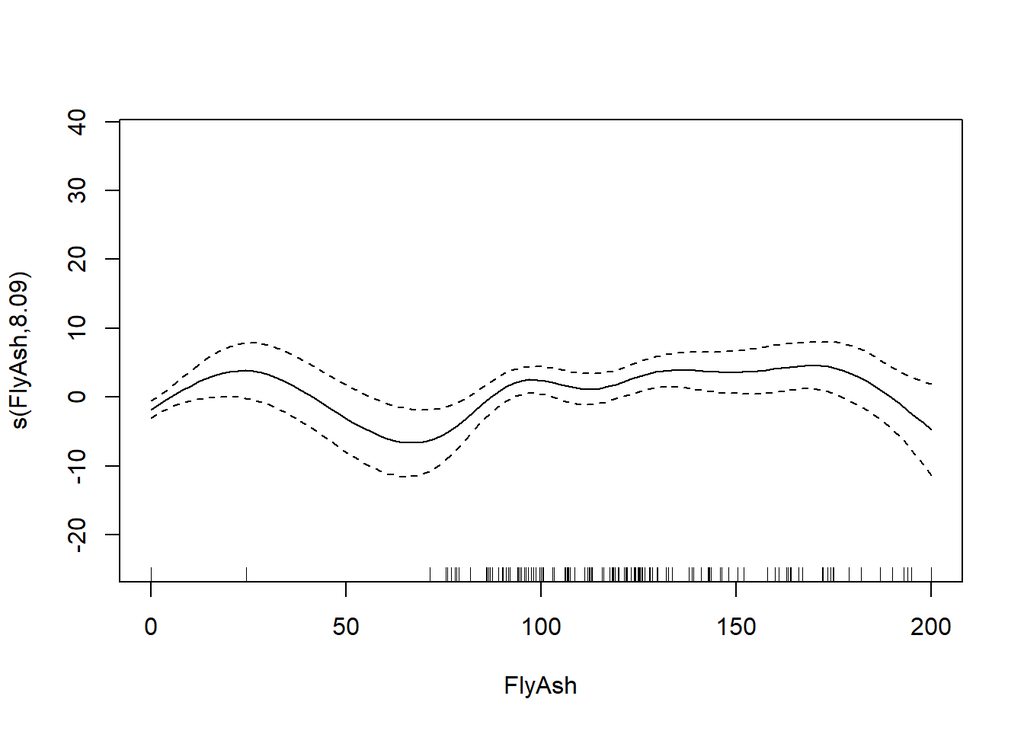

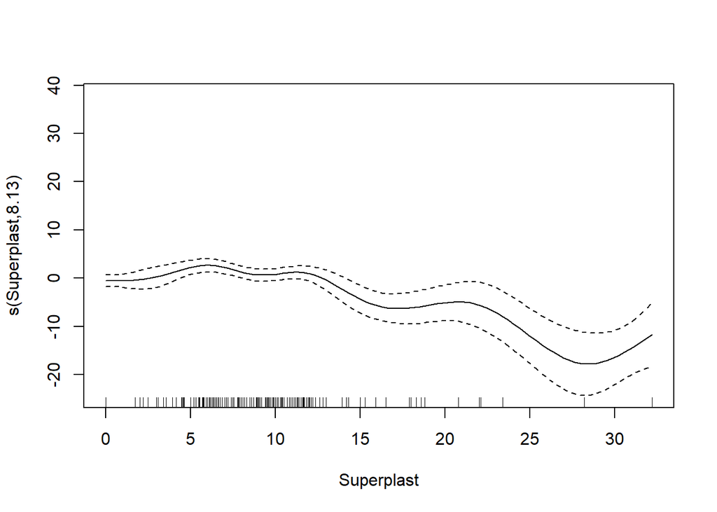

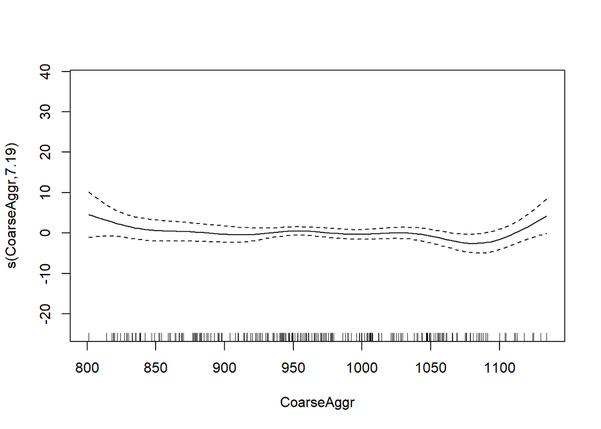

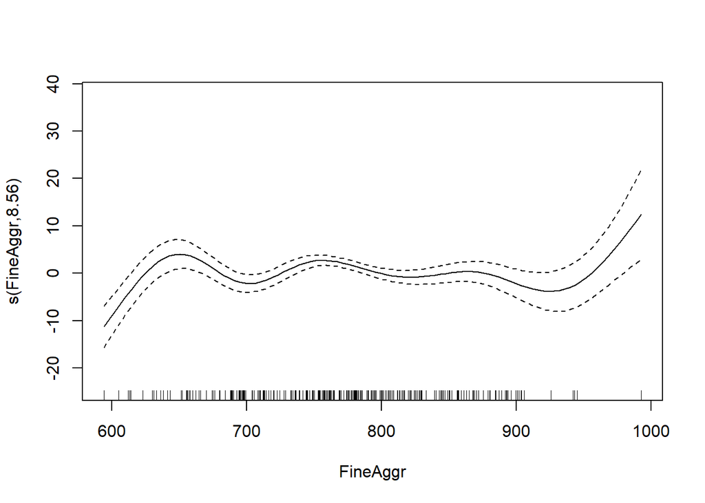

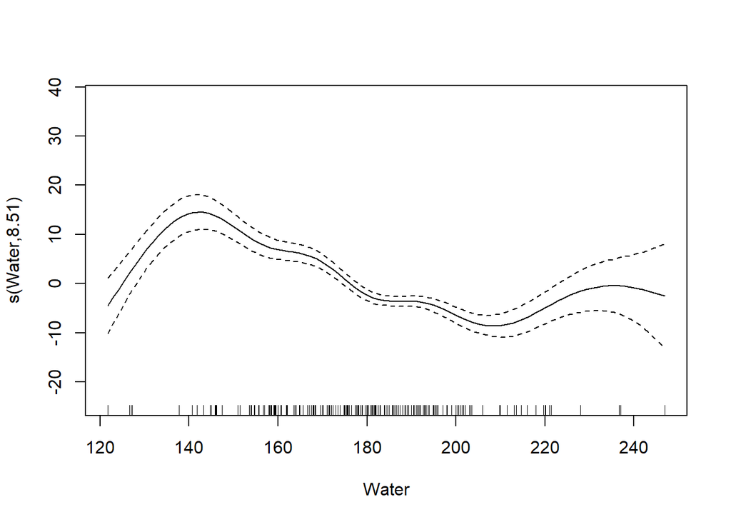

```r
plot(gam_concrete)
```

The shapley values for the Linear model and the Generalized additive model show different results for the Random Forests. Cement is clearly the most important predictor in both models, compared to Age in the Random Forests. However, in all models cement seems to be an important variables, whereas variables such as FlyAsh, Slag, and Water differ in importance depending on the model.

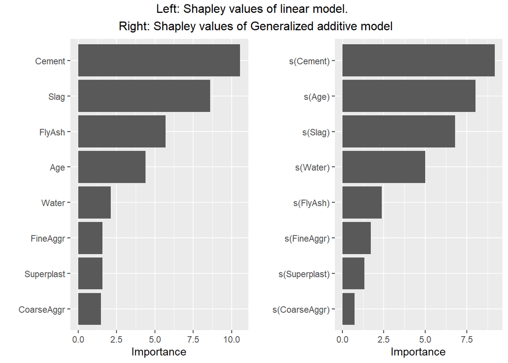

```r
lm_shapley <- vip(lm_concrete,
                  method="shap",
                  pred_wrapper=predict.lm,
                  num_features = 8,
                  newdata=test[,-9],
                  exact=TRUE)
gam_shapley <- vip(gam_concrete,
                   method="shap",
                   pred_wrapper=predict.gam,
                   num_features = 8,
                   newdata=test[,-9],
                   exact=TRUE)

grid.arrange(lm_shapley, gam_shapley, ncol=2, top="Left: Shapley values of linear model. \n Right: Shapley values of Generalized additive model")
```

# 3. Relevance by ghost variables

So far we have a Random Forest, a Linear Model, and a GAM. we want to compare the relevance for ghost variables, what is done is that the model is fitted with the original variables on the training set, but on the test set, the accuracy is computed changing $Z$ for $E(Z \mid X)$. The relevance of a variable, which can be seen is defined as the squared subtraction (over the test set) between the predictions made with variable $Z$ and the ones made with its respective ghost variable. In other words, if the relevance for a given variable is high, that means that the predictions are very different when the variable has been changed, so it is an important one.

The figure below shows that for the GAM model, Age is the variable with the highest relevance, followed by cement. Also, the components of each eigenvector are plotted together with their explained variance (similar to PCA). The first component explains 64.6% of the variance. This first vector has high coordinate values for Age (recall that the norm of the eigenvector is 1), thus underlining the relevance of these variables. The second component represents mostly the “Cement” covariate as well as “Slag” and “FlyAsh” a vector that accounts for 18.0% of the variance.

```r
library(grid)
source("relev.ghost.var.R")
Rel_Gh_Var_gam <- relev.ghost.var(model=gam_concrete,
                              newdata = test[, -9],
                              y.ts = test[, 9],
                              func.model.ghost.var = lm
)
```

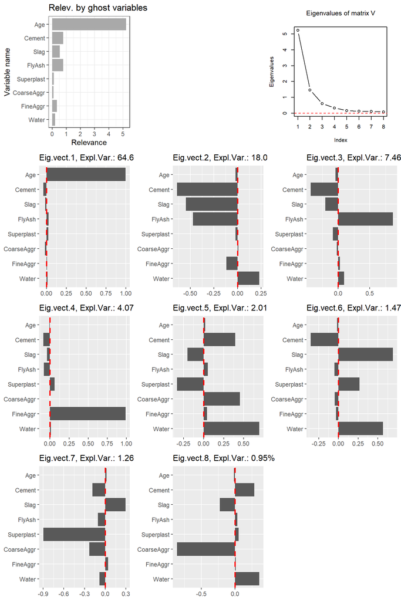

```r
plot.relev.ghost.var(Rel_Gh_Var_gam,n1=700,ncols.plot = 3)
```

For the LM, Age is also the variable with the highest relevance. However, Cement, Slag and FlyAsh seem to be playing a more important role than for the GAM. The first component explains only 48.28% of the variance, whereas the second component explains almost the same: 45.62%, which totals for 93.9% of variance explained. Just like with the GAM model, Cement, slag and FlyAsh contribute most to the second component, while Age does so for the first. Interestingly, Age also contributes a little to the second component, possible explaining the difference between the LM and GAM.

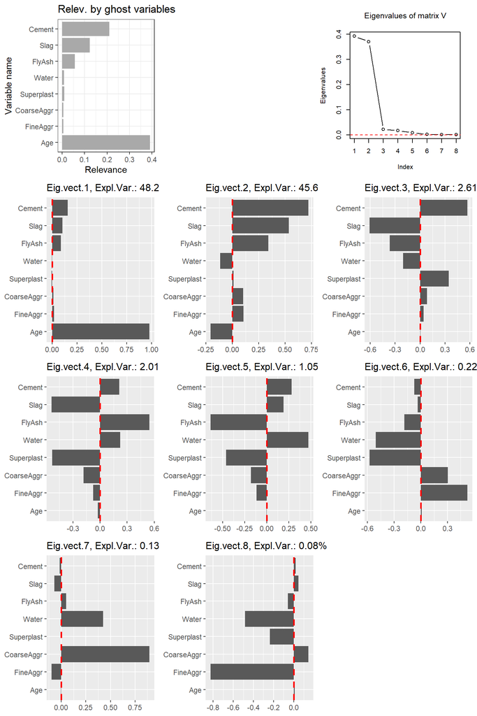

```r
Rel_Gh_Var_lm <- relev.ghost.var(model=lm_concrete,
                              newdata = test[, -9],
                              y.ts = test[, 9],
                              func.model.ghost.var = lm
)
plot.relev.ghost.var(Rel_Gh_Var_lm,n1=700,ncols.plot = 3)
```

In the case of the Random Forest, Age has again the highest relevance by far. The other variables appear in the second eigenvector but accounting for a small percentage of the explained variance.

```r
# it is necessary to create a random Forest again
rf_concrete = randomForest(Strength ~ ., data=train)


Rel_Gh_Var_rf <- relev.ghost.var(model=rf_concrete,
                              newdata = test[, -9],
                              y.ts = test[, 9],
                              func.model.ghost.var = lm
)
```

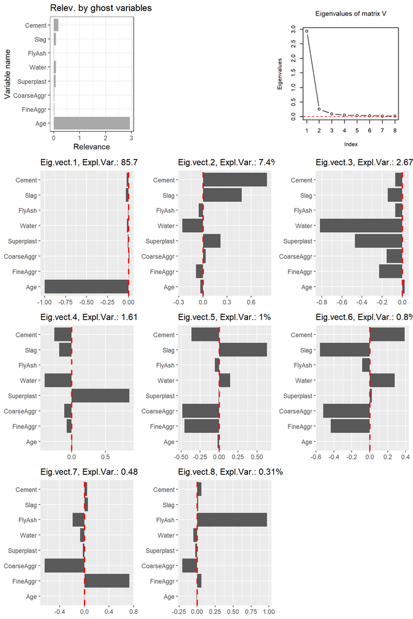

```r
plot.relev.ghost.var(Rel_Gh_Var_rf,n1=700,ncols.plot = 3)
```

# 4. Library DALEX

```r
explainer_rf <- explain.default(model = model_rf_imp,
                               data = test[, -9],
                               y = test$Strength,
                               label = "Random Forest")
```

```
## Preparation of a new explainer is initiated
##   -> model label       :  Random Forest
##   -> data              :  330  rows  8  cols
##   -> target variable   :  330  values
##   -> predict function  :  yhat.ranger  will be used (  default  )
##   -> predicted values  :  No value for predict function target column. (  default  )
##   -> model_info        :  package ranger , ver. 0.13.1 , task regression (  default  )
##   -> predicted values  :  numerical, min =  8.99662 , mean =  35.46248 , max =  76.30324
##   -> residual function :  difference between y and yhat (  default  )
##   -> residuals         :  numerical, min =  -19.89475 , mean =  -0.09154271 , max =  24.07009
##   A new explainer has been created!
```

1. Plot for variable importance

```r
Rnd_Perm <- model_parts(
  explainer_rf,
  N = NULL, # All available data are used
  B = 10   # number of permutations to be used, with B = 10 used by default
)

Rnd_Perm
```

```
##        variable mean_dropout_loss         label
## 1  _full_model_          6.015247 Random Forest
## 2        FlyAsh          6.655383 Random Forest
## 3    CoarseAggr          6.679528 Random Forest
## 4      FineAggr          7.091088 Random Forest
## 5          Slag          7.250037 Random Forest
## 6    Superplast          7.598292 Random Forest
## 7         Water          8.908290 Random Forest
## 8        Cement         10.779697 Random Forest
## 9           Age         14.003328 Random Forest
## 10   _baseline_         20.832837 Random Forest
```

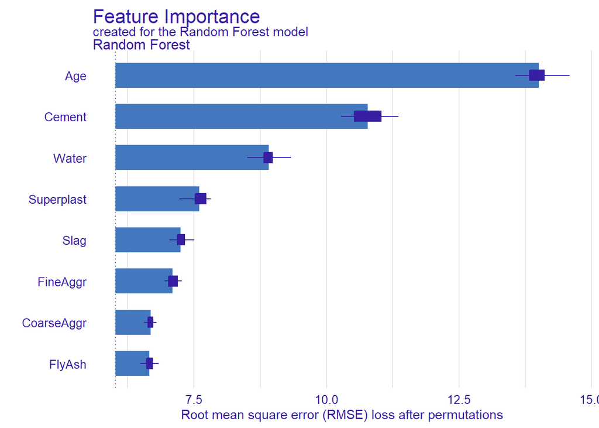

```r
plot(Rnd_Perm)
```

2. Do the Partial Dependence Plot for each explanatory variable. Once again, Age and Cement are the variables that show the most variation in the range of the prediction, which can indicate their influence on the prediction. One can note that water has a big range of values in the prediction, however it showed very low relevance in section 3. This is because PDP fail to capture explainibility when the variables are not independent.

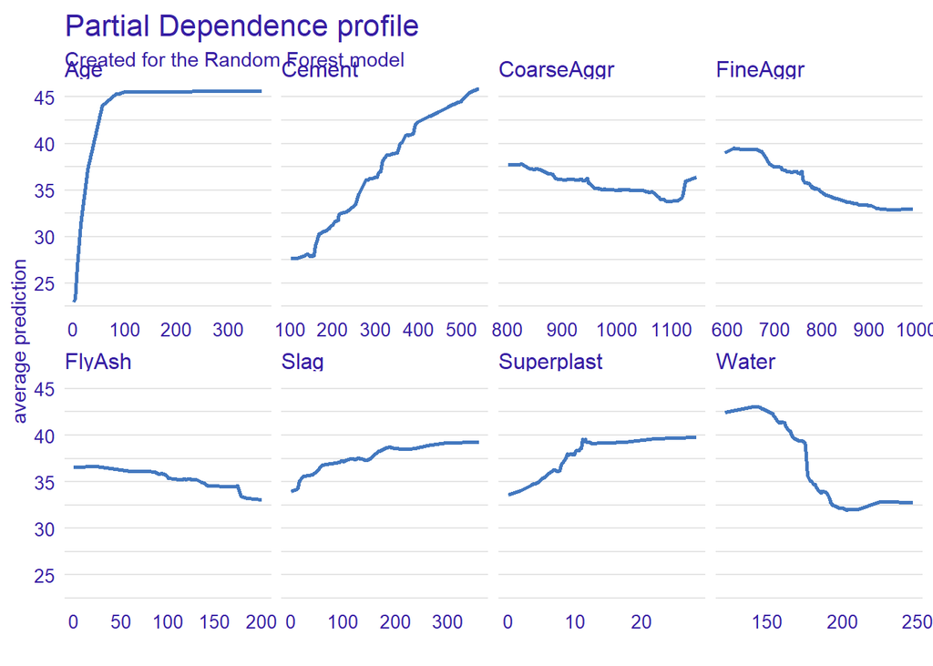

```r
PDP_rf <- model_profile(
  explainer=explainer_rf,
  variables = NULL,  # All variables are used
  N = NULL, # All available data are used
  groups = NULL,
  k = NULL,
  center = TRUE,
  type = "partial" #  partial, conditional or accumulated
)

plot(PDP_rf, facet_ncol=4)
```

3. Do the Local (or Conditional) Dependence Plot for each explanatory variable.

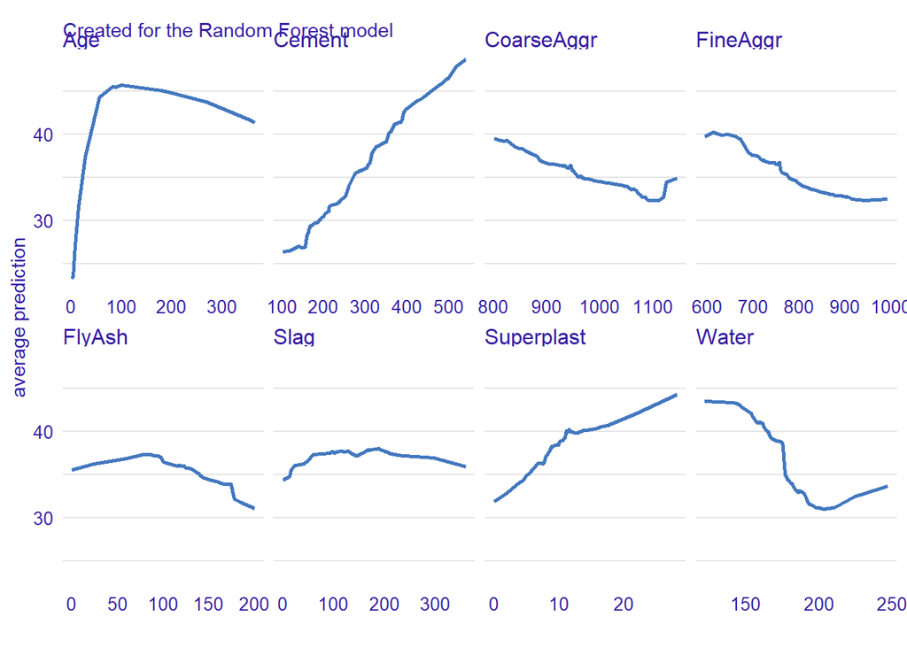

```r
CDP_rf <- model_profile(
  explainer=explainer_rf,
  variables = NULL,  # All variables are used
  N = NULL, # All available data are used
  groups = NULL,
  k = NULL,
  center = TRUE,
  type = "conditional" #  partial, conditional or accumulated
)

plot(CDP_rf, facet_ncol=4)
```

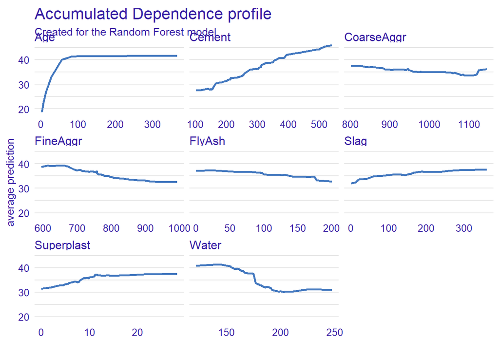

```r
# ?model_profile
ALE_rf <- model_profile(
  explainer=explainer_rf,
  variables = NULL,  # All variables are used
  N = NULL, # All available data are used
  groups = NULL,
  k = NULL,
  center = TRUE,
  type = "accumulated" #  partial, conditional or accumulated
)

plot(ALE_rf)
```

# 5. Local explainers with library DALEX

```r
minstrength_idx <- which.min(test$Strength)
maxstrength_idx <- which.max(test$Strength)

minstrength<- test[minstrength_idx, ]
maxstrength<- test[maxstrength_idx, ]
```

1. Using SHAP, we can study the contribution of each feature in the prediction, given a specific observation. The *Shapley value* is defined as the difference in expected value between the prediction considering feature $j$ and the prediction. This comes from cooperative game theory where the Shapley Value is defined as the marginal contribution of a player to a set of players that cooperate.

The idea of the following two interpretability plots via SHAP is that we can comprehend the contribution of each variable . Observe that the first one is regarding the smallest value of strength, and the second plot studies the contribution of variables to the highest predicted value of strength. It is clear that kg/$m^3$ of cement is important, as a low value contributes negatively (in the sense of low) to the prediction of strength, as well as its low age. The only clear positive contribution is water, although high variability in the computation of the Shapley value is noted. In the second plot, a high value of cement seems to be the biggest contribution to the prediction in Strength. Recall that the line in 0 indicates the average prediction.

```r
bd_rf <- predict_parts(explainer = explainer_rf,
                 new_observation = minstrength,
                            type = "shap")

bd_rf
```

```
##                                          min           q1      median
## Random Forest: Age = 3           -13.6095502 -12.72982072 -12.2265959
## Random Forest: Cement = 182       -6.1146895  -5.82411106  -5.3082504
## Random Forest: CoarseAggr = 1059  -2.0841909  -1.57904291  -1.1257380
## Random Forest: FineAggr = 780.6   -1.2242006  -1.11895445  -0.7447906
## Random Forest: FlyAsh = 122       -1.9164324  -1.15174159  -0.7215368
## Random Forest: Slag = 45.21       -0.4709490  -0.02112463   0.2804671
## Random Forest: Superplast = 8.19  -0.4539140  -0.12663169   0.8356780
## Random Forest: Water = 170.2       0.3077271   1.70397072   2.3723619
##                                         mean          q3          max
## Random Forest: Age = 3           -12.4760508 -12.1143667 -11.55792384
## Random Forest: Cement = 182       -5.3106824  -4.8590416  -4.13472947
## Random Forest: CoarseAggr = 1059  -1.2460878  -0.8575590  -0.65262547
## Random Forest: FineAggr = 780.6   -0.7594039  -0.5443512  -0.05079163
## Random Forest: FlyAsh = 122       -0.7900372  -0.1620271   0.01461365
## Random Forest: Slag = 45.21        0.1891245   0.4329197   0.66286439
## Random Forest: Superplast = 8.19   0.7046016   1.3900457   2.00457669
## Random Forest: Water = 170.2       2.3480240   3.3297736   3.96946126
```

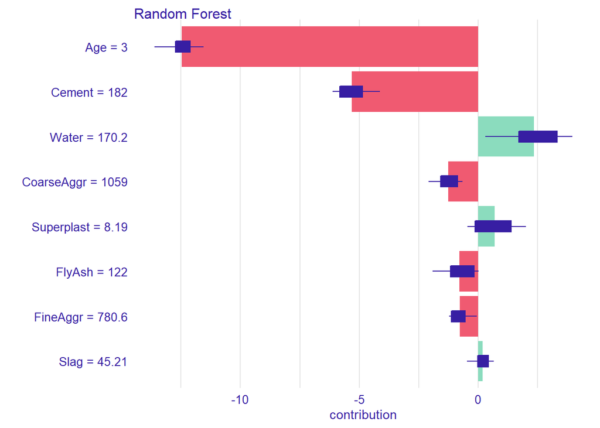

```r
plot(bd_rf)
```

```r
bd_rf <- predict_parts(explainer = explainer_rf,
                 new_observation = maxstrength,
                            type = "shap")

bd_rf
```

```
##                                         min         q1      median        mean
## Random Forest: Age = 28           1.3216493  1.8863604  2.97092565  2.93904633
## Random Forest: Cement = 540       9.8231065 10.3562971 11.02146612 11.25177153
## Random Forest: CoarseAggr = 1040 -0.7560064 -0.5564090 -0.40313640 -0.21167379
## Random Forest: FineAggr = 676     2.3787148  3.0251912  3.28756739  3.35124771
## Random Forest: FlyAsh = 0         0.8876027  1.0804958  1.33438131  1.35994600
## Random Forest: Slag = 0          -1.5786740 -0.9042744  0.04126972 -0.02461253
## Random Forest: Superplast = 2.5  -1.3543869 -0.3968416 -0.07417773  0.02931222
## Random Forest: Water = 162        4.5910705  5.4046832  5.77650606  5.80239259
##                                           q3       max
## Random Forest: Age = 28           3.80320386  4.355239
## Random Forest: Cement = 540      12.12711992 13.631055
## Random Forest: CoarseAggr = 1040  0.08439351  0.835095
## Random Forest: FineAggr = 676     3.65755231  4.185594
## Random Forest: FlyAsh = 0         1.57950135  2.027504
## Random Forest: Slag = 0           0.92283476  1.255624
## Random Forest: Superplast = 2.5   0.68302762  1.120699
## Random Forest: Water = 162        6.18464735  6.779130
```

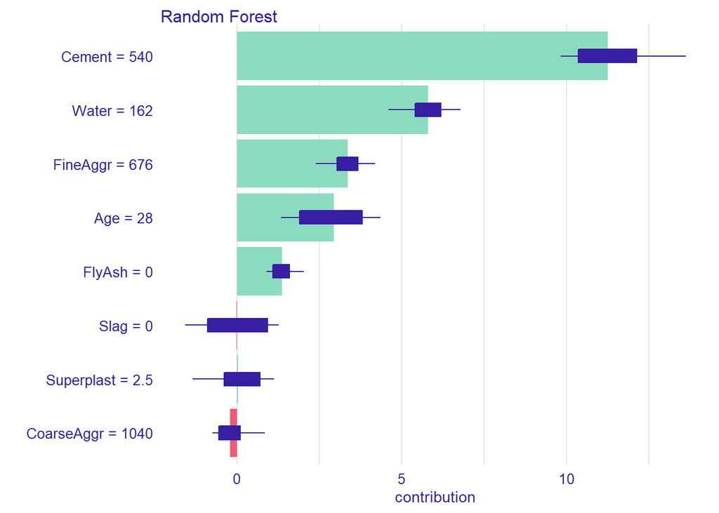

```r
plot(bd_rf)
```

2. Explain the predictions using Break-down plots

Plot for minimum strength:

```r
bd_rf <- predict_parts(explainer = explainer_rf,
                 new_observation = minstrength,
                            type = "break_down")

bd_rf
```

```
##                                  contribution
## Random Forest: intercept               35.462
## Random Forest: Age = 3                -12.227
## Random Forest: Cement = 182            -4.224
## Random Forest: Water = 170.2            3.129
## Random Forest: Superplast = 8.19        0.510
## Random Forest: CoarseAggr = 1059       -1.483
## Random Forest: Slag = 45.21            -0.033
## Random Forest: FineAggr = 780.6        -1.097
## Random Forest: FlyAsh = 122            -1.916
## Random Forest: prediction              18.122
```

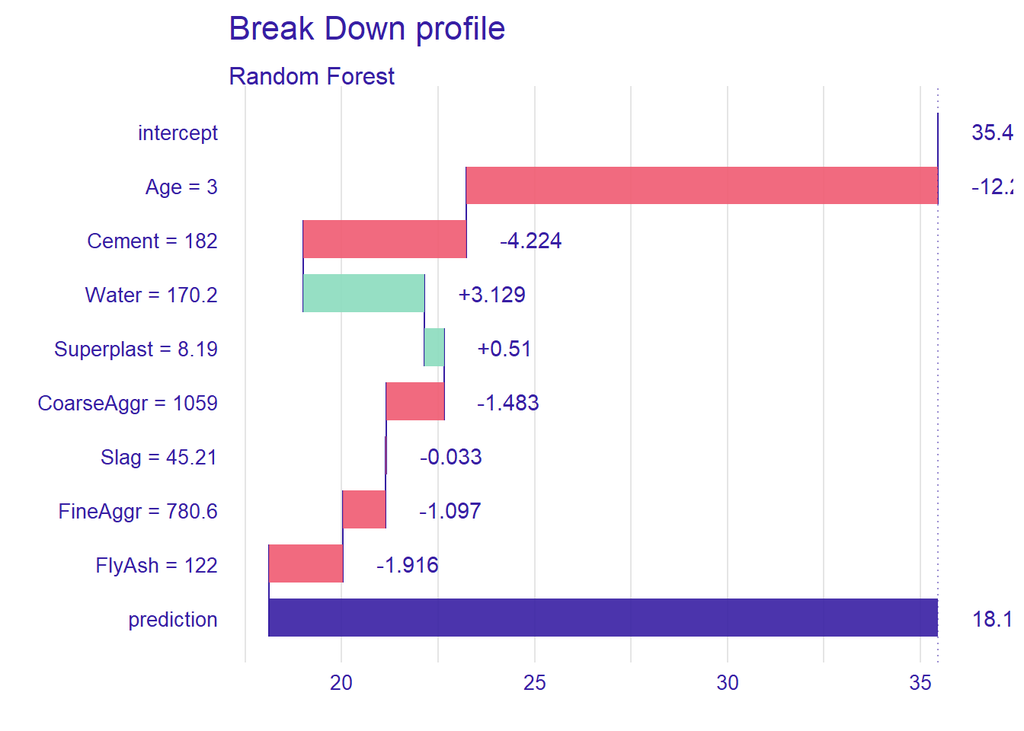

```r
plot(bd_rf)
```

Plot for maximum strength

```r
bd_rf <- predict_parts(explainer = explainer_rf,
                 new_observation = maxstrength,
                            type = "break_down")

bd_rf
```

```
##                                  contribution
## Random Forest: intercept               35.462
## Random Forest: Cement = 540            10.356
## Random Forest: Water = 162              5.075
## Random Forest: FineAggr = 676           2.379
## Random Forest: Age = 28                 3.098
## Random Forest: Slag = 0                -0.054
## Random Forest: FlyAsh = 0               1.959
## Random Forest: Superplast = 2.5         0.850
## Random Forest: CoarseAggr = 1040        0.835
## Random Forest: prediction              59.960
```

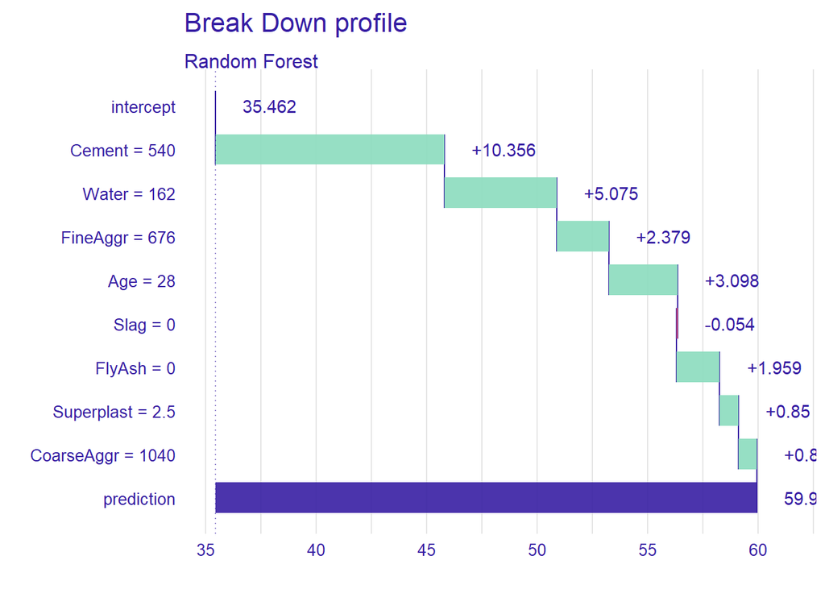

```r
plot(bd_rf)
```

3. LIME selects “recognizable properties”. In the first case, low values for cement are seen to have negative influence on the prediction.

```r
lime_rf <- predict_surrogate(explainer = explainer_rf,
                  new_observation = minstrength,
                  type = "localModel")

lime_rf
```

```
##   estimated                 variable original_variable dev_ratio response
## 1 35.462481             (Model mean)                   0.2485777
## 2 38.222638              (Intercept)                   0.2485777
## 3 -6.273913         Cement <= 212.25            Cement 0.2485777
## 4  0.000000            Slag <= 47.45              Slag 0.2485777
## 5  0.000000 96.18 < FlyAsh <= 163.81            FlyAsh 0.2485777
## 6  3.433814       154 < Water <= 182             Water 0.2485777
##   predicted_value         model
## 1        18.12197 Random Forest
## 2        18.12197 Random Forest
## 3        18.12197 Random Forest
## 4        18.12197 Random Forest
## 5        18.12197 Random Forest
## 6        18.12197 Random Forest
```

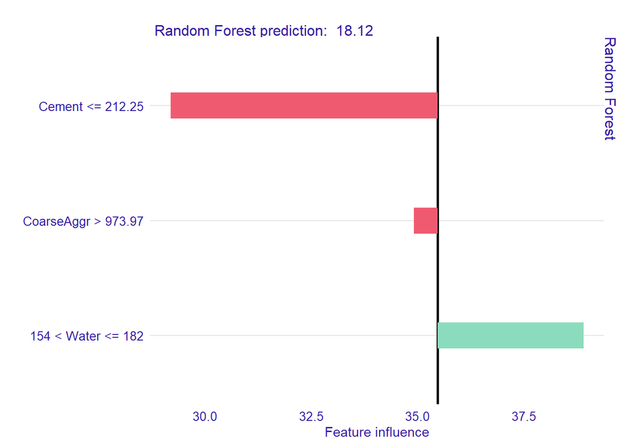

```r
plot(lime_rf)
```

In the second plot, high values for cement seem to have the biggest influence on the prediction, as seen before.

```r
lime_rf <- predict_surrogate(explainer = explainer_rf,
                  new_observation = maxstrength,
                  type = "localModel")

lime_rf
```

```
##    estimated        variable original_variable dev_ratio response
## 1 35.4624814    (Model mean)                   0.4581907
## 2 35.2328061     (Intercept)                   0.4581907
## 3 11.1781455    Cement > 349            Cement 0.4581907
## 4 -1.2143152      Slag <= 24              Slag 0.4581907
## 5  0.9458722 FlyAsh <= 90.82            FlyAsh 0.4581907
## 6  4.7687840 Water <= 164.95             Water 0.4581907
##   predicted_value         model
## 1        59.95991 Random Forest
## 2        59.95991 Random Forest
## 3        59.95991 Random Forest
## 4        59.95991 Random Forest
## 5        59.95991 Random Forest
## 6        59.95991 Random Forest
```

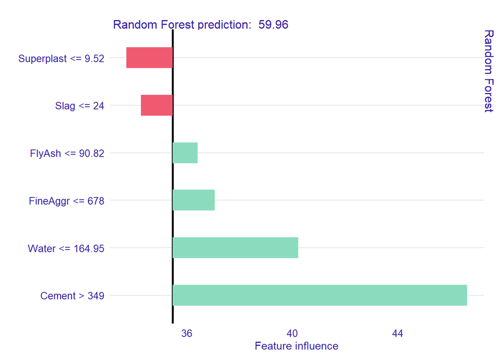

```r
plot(lime_rf)
```

4. ICE plot: The characteristic about this display is that given an observation, (i.e. min strength), it returns the values for this observation except for a set column (for example age). Then, it plots all the predictions with these values fixed while varying the age across its range [$\min$(age), $\max$(age)]. The blue dot is the value of the with the original “min strength data”. (which except age, does not vary). This procedure is repeated for all $j=1\div n$ explanatory variables.

```r
cp_rf <- predict_profile(explainer = explainer_rf,
                           new_observation = minstrength)
cp_rf
```

```
## Top profiles    :
##       Cement  Slag FlyAsh  Water Superplast CoarseAggr FineAggr Age   _yhat_
## 290   102.00 45.21 121.97 170.21       8.19     1059.4   780.65   3 17.15123
## 290.1 106.38 45.21 121.97 170.21       8.19     1059.4   780.65   3 17.15123
## 290.2 110.76 45.21 121.97 170.21       8.19     1059.4   780.65   3 17.15123
## 290.3 115.14 45.21 121.97 170.21       8.19     1059.4   780.65   3 17.16037
## 290.4 119.52 45.21 121.97 170.21       8.19     1059.4   780.65   3 17.21191
## 290.5 123.90 45.21 121.97 170.21       8.19     1059.4   780.65   3 17.22278
##       _vname_ _ids_       _label_
## 290    Cement   290 Random Forest
## 290.1  Cement   290 Random Forest
## 290.2  Cement   290 Random Forest
## 290.3  Cement   290 Random Forest
## 290.4  Cement   290 Random Forest
## 290.5  Cement   290 Random Forest
##
##
## Top observations:
##     Cement  Slag FlyAsh  Water Superplast CoarseAggr FineAggr Age   _yhat_
## 290 182.04 45.21 121.97 170.21       8.19     1059.4   780.65   3 18.12197
##           _label_ _ids_
## 290 Random Forest     1
```

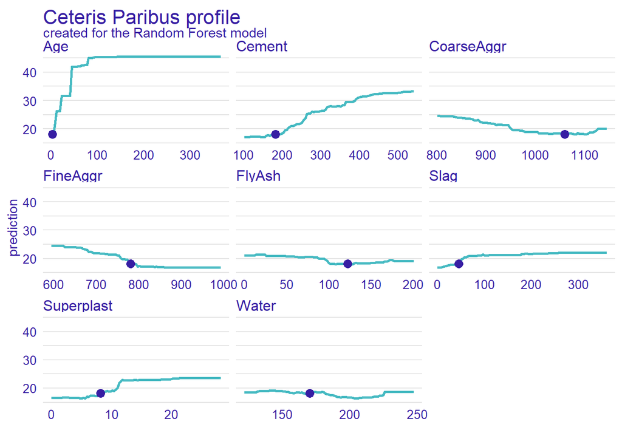

```r
plot(cp_rf)
```

```r
cp_rf <- predict_profile(explainer = explainer_rf,
                           new_observation = maxstrength)
cp_rf
```

```
## Top profiles    :
##     Cement Slag FlyAsh Water Superplast CoarseAggr FineAggr Age   _yhat_
## 1   102.00    0      0   162        2.5       1040      676  28 36.34705
## 1.1 106.38    0      0   162        2.5       1040      676  28 36.34705
## 1.2 110.76    0      0   162        2.5       1040      676  28 36.34705
## 1.3 115.14    0      0   162        2.5       1040      676  28 36.34705
## 1.4 119.52    0      0   162        2.5       1040      676  28 36.36011
## 1.5 123.90    0      0   162        2.5       1040      676  28 36.36011
##     _vname_ _ids_       _label_
## 1    Cement     1 Random Forest
## 1.1  Cement     1 Random Forest
## 1.2  Cement     1 Random Forest
## 1.3  Cement     1 Random Forest
## 1.4  Cement     1 Random Forest
## 1.5  Cement     1 Random Forest
##
##
## Top observations:
##   Cement Slag FlyAsh Water Superplast CoarseAggr FineAggr Age   _yhat_
## 1    540    0      0   162        2.5       1040      676  28 59.95991
##         _label_ _ids_
## 1 Random Forest     1
```

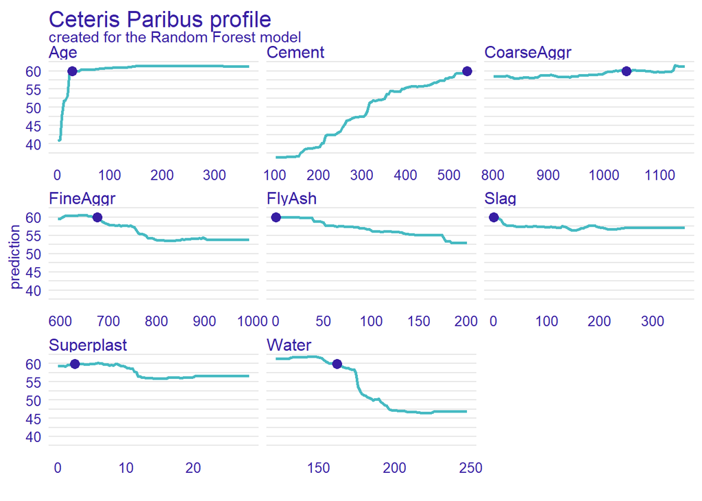

```r
plot(cp_rf)
```

5. The behaviour of age variable for each profile of data (all the other variables are fixed) shows how the prediction changes whist the age changes. As shown in Theory lectures, the PDP and the average profile of ICE’s coincide.

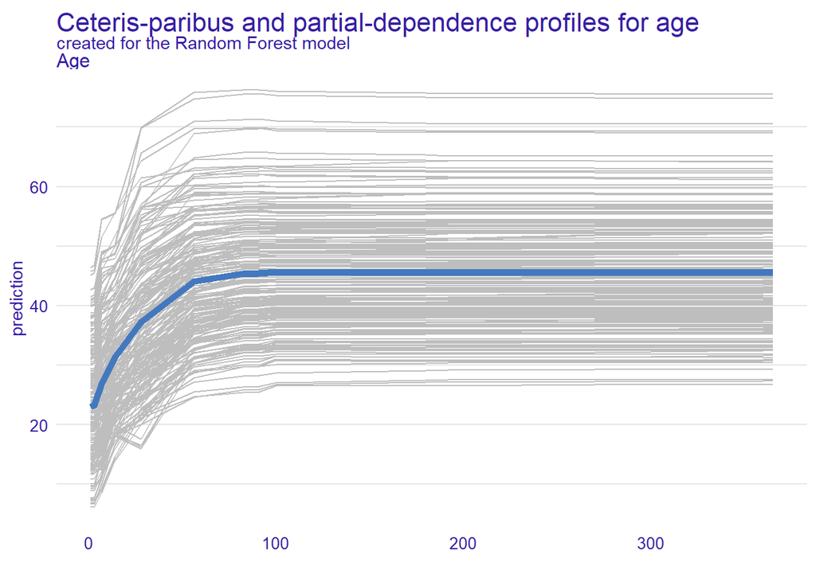

```r
mp_rf <- model_profile(explainer = explainer_rf,
  variables = "Age",
  N = NULL,
  type = "partial"
)

plot(mp_rf, geom = "profiles") +
  ggtitle("Ceteris-paribus and partial-dependence profiles for age")
```

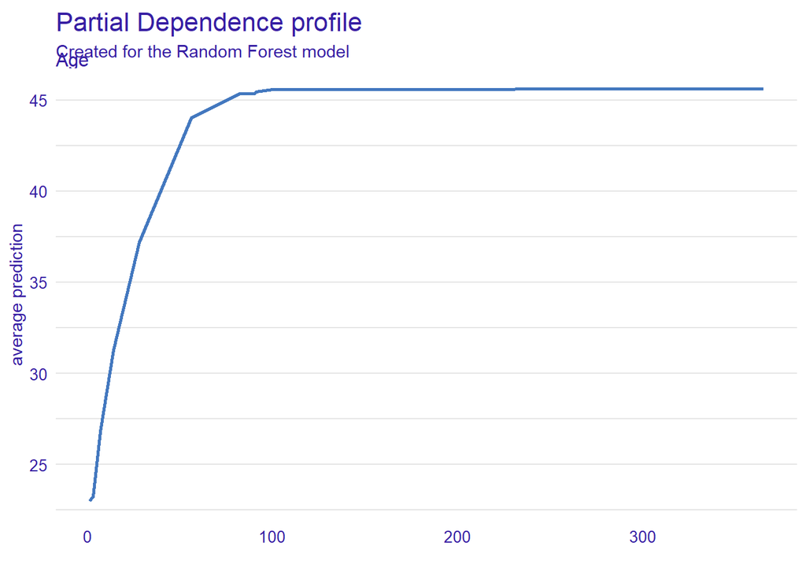

```r
PDP_rf <- model_profile(
  explainer=explainer_rf,
  variables = "Age",  # All variables are used
  N = NULL, # All available data are used
  groups = NULL,
  k = NULL,
  center = TRUE,
  type = "partial" #  partial, conditional or accumulated
)

plot(PDP_rf, facet_ncol=4)
```